# **CMSC320 Final Project - Sleep Health and Stress Data Analysis**

## **Spring 2026 Data Science Project**

## **Contributions**

Christiana: Helped brainstorm to decide the project idea and dataset to analyze (A), Basic data observation (data type /info), reformatted gender column, fixed null entries (B), T-test hypothesis testing for physical activity and quality of sleep (C), Wrote insights on each section and final conclusion (F).

Erica: Helped brainstorm to decide the project idea and dataset to analyze (A), and processed the “Occupation” column to standardize similar occupations (such as Cardiologist Doctor -> Doctor) (B). Wrote a hypothesis test for the Spearman Rank Correlation comparing sleep duration and stress, and plotted in onto a scatterplot (C). Performed the Decision Tree training, model evaluation with accuracy and a confusion matrix, and found feature importances (E).

Beatrice: Helped brainstorm to decide the project idea and dataset to analyze (A), Helped with correlation and graphing steps (C), created visualizations including a decision tree, confusion matrix, and bar plot for importances of features (F).

Jamie: Helped brainstorm to decide the project idea and dataset to analyze (A), Processed BMI inconsistent classification and duplicate row entries (B), Kruskal Wallis hypothesis testing for blood pressure categories and stress (C), Wrote introduction for project topic and data being analyzed, Organized and reviewed findings into final tutorial report (G).

Ivan: Helped brainstorm to decide the project idea and dataset to analyze (A), extracted systolic and diastolic blood pressures from the 'Blood Pressure' column, added a 'Blood Pressure Category' column, and grouped people into an Age Group' column (B), charted occupation vs. mean stress level, occupation vs. mean sleep duration, and age group vs. mean sleep duration, and determined outliers in the data (C), performed feature engineering and feature encoding to prepare the decision tree for modeling (D), performed an accuracy and classification report on the training data and compared it with the test data to check if the model was overfitting (E).

## **Introduction**

A healthy lifestyle is vital for mental health and reduced stress levels. However, what health related factors specifically impact stress? To answer this question, other questions to identify specific factors affecting sleep and stress should be explored first. Some example questions to identify factors that raise stress levels include: Does occupation impact hours of sleep? Is there correlation between age and sleep? Does duration of sleep affect stress levels? Do sleep disorders affect a person's stress level? Does blood pressure affect stress? Does physical activity level impact sleep quality?  
Through these findings, people can build a better understanding of what factors cause stress to develop. The conclusions found can be applied beyond this project to encourage others to build better stress management strategies. For example, if we determine that certain sleep disorders increase stress, people should consider how they can change their other lifestyle habits to lower their overall stress. On the other hand, if we determine that people with a higher daily step count have lower stress levels, then people with high stress levels could consider going on more walks throughout the day. With these findings on what specific factors impact stress, these individuals can determine what aspects of their life to change in order to optimize and reduce their stress levels. Overall, people can work towards reducing their stress levels by attempting to alter or improve the most significant factors that affect stress.

## **Data Curation**

The data is from a Kaggle dataset, titled the [Sleep Health and Lifestyle Database](https://www.kaggle.com/datasets/uom190346a/sleep-health-and-lifestyle-dataset). The chosen dataset has a variety of characteristics recorded such as occupation, daily steps, stress level, and sleep disorders which makes it valuable for analysis. With analysis, it can reveal what factors influence sleep the most and help to draw conclusions on what actions people can take to improve their sleep health. The chosen dataset is given with 379 entries each seeming to represent a person with a personal ID number. The 13 columns include Person ID, Gender, Age, Occupation, Sleep Duration, Quality of Sleep, Physical Activity Level, Stress Level, BMI Category, Blood Pressure, Heart Rate, Daily Steps, and Sleep Disorder.

## **Data Preprocessing**

- Import data
- Check data types of columns
- Check range of data: info(), count(), nunqiue()

```python
import pandas as pd

# Import Dataset
url = 'https://raw.githubusercontent.com/jlee8823/CMSC320-final-project/refs/heads/main/Sleep_health_and_lifestyle_dataset.csv'
df = pd.read_csv(url)

display(df)
```

|  | Person ID | Gender | Age | Occupation | Sleep Duration | Quality of Sleep | Physical Activity Level | Stress Level | BMI Category | Blood Pressure | Heart Rate | Daily Steps | Sleep Disorder |
| --- | --- | --- | --- | --- | --- | --- | --- | --- | --- | --- | --- | --- | --- |
| 0 | 1 | Male | 27 | Software Engineer | 6.1 | 6 | 42.0 | 6 | Overweight | 126/83 | 77 | 4200 | NaN |
| 1 | 2 | M | 28 | Doctor | 6.2 | 6 | 60.0 | 8 | Normal | 125/80 | 75 | 10000 | NaN |
| 2 | 3 | male | 28 | Cardiology Doctor | 6.2 | 6 | 60.0 | 8 | Normal | 125/80 | 75 | 10000 | NaN |
| 3 | 4 | male | 28 | Sales Representative | 5.9 | 4 | 30.0 | 8 | Obese | 140/90 | 85 | 3000 | Sleep Apnea |
| 4 | 5 | M | 28 | SALES REPRESENTATIVE | 5.9 | 4 | 30.0 | 8 | Obese | 140/90 | 85 | 3000 | Sleep Apnea |
| ... | ... | ... | ... | ... | ... | ... | ... | ... | ... | ... | ... | ... | ... |
| 374 | 370 | Female | 59 | Nurse | 8.1 | 9 | 75.0 | 3 | Overweight | 140/95 | 68 | 7000 | Sleep Apnea |
| 375 | 371 | F | 59 | Nurse | 8.0 | 9 | 75.0 | 3 | Overweight | 140/95 | 68 | 7000 | Sleep Apnea |
| 376 | 372 | Female | 59 | Nurse | 8.1 | 9 | NaN | 3 | Overweight | 140/95 | 68 | 7000 | Sleep Apnea |
| 377 | 373 | female | 59 | NURSE | 8.1 | 9 | 75.0 | 3 | Overweight | 140/95 | 68 | 7000 | Sleep Apnea |
| 378 | 374 | F | 59 | Nurse | 8.1 | 9 | 75.0 | 3 | Overweight | 140/95 | 68 | 7000 | Sleep Apnea |

379 rows × 13 columns

Through obseving the dataset, it is obvious there are many inconsistencies. There are several null entries throughout the dataset. Gender is represented in multiple ways (i.e. Female, F, female, M, male) leading to inconsistent formatting. The occupation column is also inconsistent as the job titles range in formatting with all capitalized and different specialized versions of the same job. BMI also has inconsistencies in how Normal is categorized with 'Normal Weight' and 'Normal' both as options. Blood pressure is currently in the systolic over diastolic values which are not easily understandle to an everyday person without knowledge of blood pressure values. There are also row entries with the same person ID repeated throughout the dataset. All these irregularities in the data must be cleaned for more accurate data manipulation.

```python
# Checking data types and info
display(df.dtypes)

info = df.count()
display(info)
```

|  | 0 |
| --- | --- |
| Person ID | int64 |
| Gender | object |
| Age | int64 |
| Occupation | object |
| Sleep Duration | float64 |
| Quality of Sleep | int64 |
| Physical Activity Level | float64 |
| Stress Level | int64 |
| BMI Category | object |
| Blood Pressure | object |
| Heart Rate | int64 |
| Daily Steps | int64 |
| Sleep Disorder | object |

**dtype:** object

|  | 0 |
| --- | --- |
| Person ID | 379 |
| Gender | 379 |
| Age | 379 |
| Occupation | 379 |
| Sleep Duration | 379 |
| Quality of Sleep | 379 |
| Physical Activity Level | 349 |
| Stress Level | 379 |
| BMI Category | 379 |
| Blood Pressure | 379 |
| Heart Rate | 379 |
| Daily Steps | 379 |
| Sleep Disorder | 155 |

**dtype:** int64

## **Cleaning Data**

For more accurate analysis of the data, it is necessary to:

- Re-format necessary columns
- Get rid of duplicate rows
- Fill in null entries appropriately

To ensure that future visualizations, analysis, and modeling are accurate, we clean the data. For example, the "Gender" column has multiple variations of the same gender, such as "F" and "Female", which we standardize into one possible representation.

```python
# Cleaning Gender Column into two categories (F, M)
df.loc[df['Gender'].str.contains('f', case=False), 'Gender'] = 'F'
df.loc[df['Gender'].str.contains('male', case=False), 'Gender'] = 'M'
```

To reduce the variety of column values for "Occupation", we group similar occupations into one category, such as making variations of doctor, such as Cardiologist Doctor vs. Pediatric Doctor into just Doctor. We also make capitalizations consistent.

```python
# Cleaning Occupation Column
df["Occupation"] = df["Occupation"].str.title()

general_occupations = ["Doctor", "Nurse", "Lawyer", "Accountant", "Engineer", "Teacher", "Salesperson",
                       "Sales Representative"]
def get_general_occupation(occupation, general_occupations): # Cleans variations of same job (such as "Pediatric Doctor" -> "Doctor")
  for general_occ in general_occupations:
    if general_occ in str(occupation):
      return general_occ
  return occupation

df["Occupation"] = df["Occupation"].apply(lambda x: get_general_occupation(x, general_occupations))
display(df.head())
```

|  | Person ID | Gender | Age | Occupation | Sleep Duration | Quality of Sleep | Physical Activity Level | Stress Level | BMI Category | Blood Pressure | Heart Rate | Daily Steps | Sleep Disorder |
| --- | --- | --- | --- | --- | --- | --- | --- | --- | --- | --- | --- | --- | --- |
| 0 | 1 | M | 27 | Engineer | 6.1 | 6 | 42.0 | 6 | Overweight | 126/83 | 77 | 4200 | NaN |
| 1 | 2 | M | 28 | Doctor | 6.2 | 6 | 60.0 | 8 | Normal | 125/80 | 75 | 10000 | NaN |
| 2 | 3 | M | 28 | Doctor | 6.2 | 6 | 60.0 | 8 | Normal | 125/80 | 75 | 10000 | NaN |
| 3 | 4 | M | 28 | Sales Representative | 5.9 | 4 | 30.0 | 8 | Obese | 140/90 | 85 | 3000 | Sleep Apnea |
| 4 | 5 | M | 28 | Sales Representative | 5.9 | 4 | 30.0 | 8 | Obese | 140/90 | 85 | 3000 | Sleep Apnea |

Similarly, we clean other columns such as BMI and Blood Pressure.

```python
# BMI inconsistencies
df['BMI Category'].unique()
```

```
array(['Overweight', 'Normal', 'Obese', 'Normal Weight'], dtype=object)
```

```python
# Cleaning BMI
df['BMI Category'] = df['BMI Category'].replace('Normal Weight', 'Normal')
print(df['BMI Category'].unique())
display(df.head())
```

```
['Overweight' 'Normal' 'Obese']
```

|  | Person ID | Gender | Age | Occupation | Sleep Duration | Quality of Sleep | Physical Activity Level | Stress Level | BMI Category | Blood Pressure | Heart Rate | Daily Steps | Sleep Disorder |
| --- | --- | --- | --- | --- | --- | --- | --- | --- | --- | --- | --- | --- | --- |
| 0 | 1 | M | 27 | Engineer | 6.1 | 6 | 42.0 | 6 | Overweight | 126/83 | 77 | 4200 | NaN |
| 1 | 2 | M | 28 | Doctor | 6.2 | 6 | 60.0 | 8 | Normal | 125/80 | 75 | 10000 | NaN |
| 2 | 3 | M | 28 | Doctor | 6.2 | 6 | 60.0 | 8 | Normal | 125/80 | 75 | 10000 | NaN |
| 3 | 4 | M | 28 | Sales Representative | 5.9 | 4 | 30.0 | 8 | Obese | 140/90 | 85 | 3000 | Sleep Apnea |
| 4 | 5 | M | 28 | Sales Representative | 5.9 | 4 | 30.0 | 8 | Obese | 140/90 | 85 | 3000 | Sleep Apnea |

```python
# Cleaning Blood Pressure into 2 element list
bp = df['Blood Pressure'].apply(lambda x: x.split('/'))
# String to Int conversion
bp = bp.apply(lambda x: [int(num) for num in x])
# Separate into Systolic and Diastolic blood pressure
df['Systolic'] = bp.apply(lambda x: x[0])
df['Diastolic'] = bp.apply(lambda x: x[1])
# Determining Blood Pressure Category
def get_bp_category(blood_pressure):
  sys = blood_pressure[0]
  dia = blood_pressure[1]
  if sys < 120 and dia < 80:
    return 'Healthy'
  elif 120 <= sys <= 129 and dia < 80:
    return 'Elevated'
  elif 130 <= sys <= 139 or 80 <= dia <= 89:
    return 'Stage 1 Hypertension'
  elif 140 <= sys <= 179 or 90 <= dia <= 119:
    return 'Stage 2 Hypertension'
  else:
    return 'Hypertension Crisis'
df['Blood Pressure Category'] = bp.apply(get_bp_category)
display(df.head())
```

|  | Person ID | Gender | Age | Occupation | Sleep Duration | Quality of Sleep | Physical Activity Level | Stress Level | BMI Category | Blood Pressure | Heart Rate | Daily Steps | Sleep Disorder | Systolic | Diastolic | Blood Pressure Category |
| --- | --- | --- | --- | --- | --- | --- | --- | --- | --- | --- | --- | --- | --- | --- | --- | --- |
| 0 | 1 | M | 27 | Engineer | 6.1 | 6 | 42.0 | 6 | Overweight | 126/83 | 77 | 4200 | NaN | 126 | 83 | Stage 1 Hypertension |
| 1 | 2 | M | 28 | Doctor | 6.2 | 6 | 60.0 | 8 | Normal | 125/80 | 75 | 10000 | NaN | 125 | 80 | Stage 1 Hypertension |
| 2 | 3 | M | 28 | Doctor | 6.2 | 6 | 60.0 | 8 | Normal | 125/80 | 75 | 10000 | NaN | 125 | 80 | Stage 1 Hypertension |
| 3 | 4 | M | 28 | Sales Representative | 5.9 | 4 | 30.0 | 8 | Obese | 140/90 | 85 | 3000 | Sleep Apnea | 140 | 90 | Stage 2 Hypertension |
| 4 | 5 | M | 28 | Sales Representative | 5.9 | 4 | 30.0 | 8 | Obese | 140/90 | 85 | 3000 | Sleep Apnea | 140 | 90 | Stage 2 Hypertension |

Here we identify exactly what rows are duplicated in the dataset.

```python
# Check for duplicate rows
display(df[df['Person ID'].duplicated()])
```

|  | Person ID | Gender | Age | Occupation | Sleep Duration | Quality of Sleep | Physical Activity Level | Stress Level | BMI Category | Blood Pressure | Heart Rate | Daily Steps | Sleep Disorder | Systolic | Diastolic | Blood Pressure Category |
| --- | --- | --- | --- | --- | --- | --- | --- | --- | --- | --- | --- | --- | --- | --- | --- | --- |
| 13 | 13 | M | 29 | Doctor | 6.1 | 6 | NaN | 8 | Normal | 120/80 | 70 | 8000 | NaN | 120 | 80 | Stage 1 Hypertension |
| 110 | 109 | M | 37 | Engineer | 7.8 | 8 | 70.0 | 4 | Normal | 120/80 | 68 | 7000 | NaN | 120 | 80 | Stage 1 Hypertension |
| 141 | 139 | F | 38 | Accountant | 7.1 | 8 | 60.0 | 4 | Normal | 115/75 | 68 | 7000 | NaN | 115 | 75 | Healthy |
| 183 | 180 | M | 42 | Lawyer | 7.8 | 8 | 90.0 | 5 | Normal | 130/85 | 70 | 8000 | NaN | 130 | 85 | Stage 1 Hypertension |
| 335 | 331 | F | 53 | Engineer | 8.5 | 9 | 30.0 | 3 | Normal | 125/80 | 65 | 5000 | NaN | 125 | 80 | Stage 1 Hypertension |

These duplicate rows are dropped since they are identical duplicates of the existing rows and are not two different entries for the same person. Since they are completely identical, they can be dropped.

```python
# Dropping duplicate rows and reindexing
df = df.drop_duplicates(subset=['Person ID'])
df = df.reset_index(drop=True)
display(df.head())
```

|  | Person ID | Gender | Age | Occupation | Sleep Duration | Quality of Sleep | Physical Activity Level | Stress Level | BMI Category | Blood Pressure | Heart Rate | Daily Steps | Sleep Disorder | Systolic | Diastolic | Blood Pressure Category |
| --- | --- | --- | --- | --- | --- | --- | --- | --- | --- | --- | --- | --- | --- | --- | --- | --- |
| 0 | 1 | M | 27 | Engineer | 6.1 | 6 | 42.0 | 6 | Overweight | 126/83 | 77 | 4200 | NaN | 126 | 83 | Stage 1 Hypertension |
| 1 | 2 | M | 28 | Doctor | 6.2 | 6 | 60.0 | 8 | Normal | 125/80 | 75 | 10000 | NaN | 125 | 80 | Stage 1 Hypertension |
| 2 | 3 | M | 28 | Doctor | 6.2 | 6 | 60.0 | 8 | Normal | 125/80 | 75 | 10000 | NaN | 125 | 80 | Stage 1 Hypertension |
| 3 | 4 | M | 28 | Sales Representative | 5.9 | 4 | 30.0 | 8 | Obese | 140/90 | 85 | 3000 | Sleep Apnea | 140 | 90 | Stage 2 Hypertension |
| 4 | 5 | M | 28 | Sales Representative | 5.9 | 4 | 30.0 | 8 | Obese | 140/90 | 85 | 3000 | Sleep Apnea | 140 | 90 | Stage 2 Hypertension |

Null entries in the dataset, specifically they were found in the physical activity level and sleep disorder columns, are dealt with filling with the most common entry given similar conditions.

For 'Physical Activity Level', individuals with the same 'Daily Steps' and 'Heart Rate' are grouped. Those with no 'Physical Activity Level' entry have their entry filled with the mode of individuals with the same 'Daily Steps' count and 'Heart Rate'.

```python
# Fixing null entries in physcial activity based on most common among entries that have the same steps
common_steps = df.groupby(['Daily Steps', 'Heart Rate'])['Physical Activity Level'].transform(lambda x: x.mode()[0])
df['Physical Activity Level'] = df['Physical Activity Level'].fillna(common_steps)
```

Those with no entry for 'Sleep Disorder' are assumed to have none.

```python
# Null entries in Sleep Disorder to None
df['Sleep Disorder'] = df['Sleep Disorder'].fillna('None')
```

We make age groups to make the data easier to visualize and eventually model, as it simplifies the data.

```python
# Creating age groups
def age_range(min, max):
  return f'{min}-{max}'
def get_age_group(age):
  min = 25
  max = 34
  while(max < 65):
    if(age in range(min, max + 1)):
      return age_range(min,max)
    else:
      min += 10
      max += 10
  return '65+'
# Create age group column
df['Age Group'] = df['Age'].apply(get_age_group)
# Final cleaned dataset
display(df)
```

|  | Person ID | Gender | Age | Occupation | Sleep Duration | Quality of Sleep | Physical Activity Level | Stress Level | BMI Category | Blood Pressure | Heart Rate | Daily Steps | Sleep Disorder | Systolic | Diastolic | Blood Pressure Category | Age Group |
| --- | --- | --- | --- | --- | --- | --- | --- | --- | --- | --- | --- | --- | --- | --- | --- | --- | --- |
| 0 | 1 | M | 27 | Engineer | 6.1 | 6 | 42.0 | 6 | Overweight | 126/83 | 77 | 4200 | None | 126 | 83 | Stage 1 Hypertension | 25-34 |
| 1 | 2 | M | 28 | Doctor | 6.2 | 6 | 60.0 | 8 | Normal | 125/80 | 75 | 10000 | None | 125 | 80 | Stage 1 Hypertension | 25-34 |
| 2 | 3 | M | 28 | Doctor | 6.2 | 6 | 60.0 | 8 | Normal | 125/80 | 75 | 10000 | None | 125 | 80 | Stage 1 Hypertension | 25-34 |
| 3 | 4 | M | 28 | Sales Representative | 5.9 | 4 | 30.0 | 8 | Obese | 140/90 | 85 | 3000 | Sleep Apnea | 140 | 90 | Stage 2 Hypertension | 25-34 |
| 4 | 5 | M | 28 | Sales Representative | 5.9 | 4 | 30.0 | 8 | Obese | 140/90 | 85 | 3000 | Sleep Apnea | 140 | 90 | Stage 2 Hypertension | 25-34 |
| ... | ... | ... | ... | ... | ... | ... | ... | ... | ... | ... | ... | ... | ... | ... | ... | ... | ... |
| 369 | 370 | F | 59 | Nurse | 8.1 | 9 | 75.0 | 3 | Overweight | 140/95 | 68 | 7000 | Sleep Apnea | 140 | 95 | Stage 2 Hypertension | 55-64 |
| 370 | 371 | F | 59 | Nurse | 8.0 | 9 | 75.0 | 3 | Overweight | 140/95 | 68 | 7000 | Sleep Apnea | 140 | 95 | Stage 2 Hypertension | 55-64 |
| 371 | 372 | F | 59 | Nurse | 8.1 | 9 | 60.0 | 3 | Overweight | 140/95 | 68 | 7000 | Sleep Apnea | 140 | 95 | Stage 2 Hypertension | 55-64 |
| 372 | 373 | F | 59 | Nurse | 8.1 | 9 | 75.0 | 3 | Overweight | 140/95 | 68 | 7000 | Sleep Apnea | 140 | 95 | Stage 2 Hypertension | 55-64 |
| 373 | 374 | F | 59 | Nurse | 8.1 | 9 | 75.0 | 3 | Overweight | 140/95 | 68 | 7000 | Sleep Apnea | 140 | 95 | Stage 2 Hypertension | 55-64 |

374 rows × 17 columns

## **Data Exploration**

In this section, we explore:  
Graphing Distributions

Hypothesis Testing:

- Sleep duration vs Stress : Spearman Rank Correlation (non parametric test)
- Blood Pressure Category vs Stress : Kruskal Wallis test
- Physcial Activity vs Quality of sleep : T-test

Finding outliers

```python
from scipy import stats
import matplotlib.pyplot as plt
```

### **Graphing Distributions**

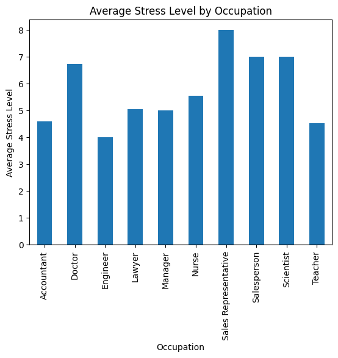

```python
mean_stress_by_occupation = df.groupby('Occupation')['Stress Level'].mean()
mean_stress_by_occupation.plot(kind='bar')
plt.xlabel('Occupation')
plt.ylabel('Average Stress Level')
plt.title('Average Stress Level by Occupation')
plt.show()
```

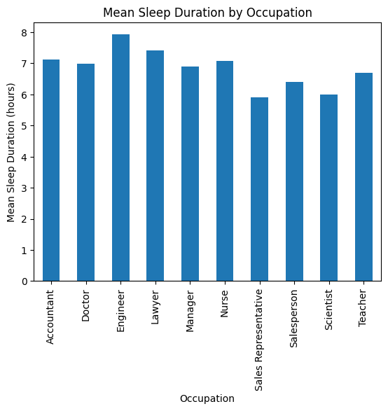

```python
mean_sleep_by_occupation = df.groupby('Occupation')['Sleep Duration'].mean()
mean_sleep_by_occupation.plot(kind='bar')
plt.xlabel('Occupation')
plt.ylabel('Mean Sleep Duration (hours)')
plt.title('Mean Sleep Duration by Occupation')
plt.show()
```

Occupations with lower sleep duration seem to have higher stress levels by comparing both figures.

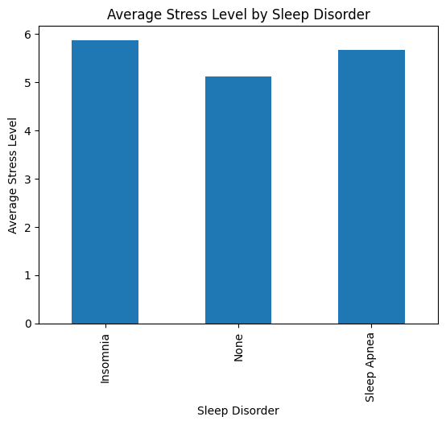

```python
mean_stress_by_disorder = df.groupby('Sleep Disorder')['Stress Level'].mean()
mean_stress_by_disorder.plot(kind='bar')
plt.xlabel('Sleep Disorder')
plt.ylabel('Average Stress Level')
plt.title('Average Stress Level by Sleep Disorder')
plt.show()
```

There is a slight difference is stress level by sleep disorder as no sleep disorder has visibly slightly lower average stress.

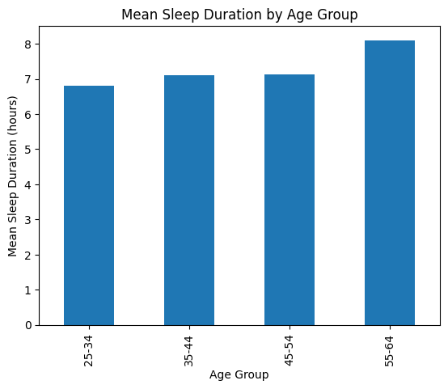

```python
sleep_by_age = df.groupby('Age Group')['Sleep Duration'].mean()
sleep_by_age.plot(kind='bar')
plt.xlabel('Age Group')
plt.ylabel('Mean Sleep Duration (hours)')
plt.title('Mean Sleep Duration by Age Group')
plt.show()
```

There is not much difference in average sleep duration between age groups. Only the oldest age group of individuals 55-64 years old having almost an extra hour of sleep.

### **Spearman rank correlation (Non-parametric test): Sleep Duration and Stress**

To compare sleep duration and stress, a Spearman rank test will be used because stress is ordinal rather than continuous. Moreover, the relationship may not be linear, and the distribution may not be normal. So, a non-parametric test will be used to measure correlation.

*Null Hypothesis*  
H0 = There is no monotonic relationship between Sleep Duration and Stress Level (p = 0)  
*Alternative Hypothesis*  
Ha = There is a monotonic relationship between Sleep Duration and Stress  
(p != 0)  
Significance Level = 0.05

```python
# spearman rank correlation
r_sleep_stress, p_value_sleep_stress = stats.spearmanr(df["Sleep Duration"], df["Stress Level"])
print(f"r = {r_sleep_stress:.4f}, p = {p_value_sleep_stress:.4f}")
```

```
r = -0.8106, p = 0.0000
```

Conclusion: Since the p-value = 0 < 0.05, we reject the null hypothesis. There is sufficient evidence to conclude that there is a monotonic relationship between Sleep Duration and Stress. Moreover, since r = -0.8106, there is a strong negative correlation between the two variables. This suggests that as sleep duration increases, stress decreases.

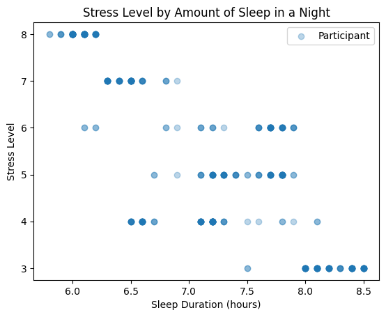

```python
# scatterplot relating sleep duration and stress level
plt.scatter(df["Sleep Duration"], df["Stress Level"], alpha=0.3, label="Participant")
plt.xlabel("Sleep Duration (hours)")
plt.ylabel("Stress Level")
plt.title("Stress Level by Amount of Sleep in a Night")
plt.legend()
plt.show()
```

### **Kruskal Wallis Testing: Blood Pressure and Stress**

Hypothesis Testing for if blood pressure affects stress score  
To first check what hypothesis test should be used, ANOVA or Kruskal Wallis since there are multiple samples being compared to each other and the stress score is ordinal, we must check if the sample sizes are all sufficiently large and relatively equally distributed.

```python
blood_pressure_df = df.groupby('Blood Pressure Category')

print(blood_pressure_df.apply(lambda x: x.shape, include_groups=False))
```

```
Blood Pressure Category
Elevated                  (1, 16)
Healthy                  (41, 16)
Stage 1 Hypertension    (261, 16)
Stage 2 Hypertension     (71, 16)
dtype: object
```

Since the individuals in the sample are not evenly distributed between the blood pressure groups and not all groups are sufficiently large, Kruskal Wallis hypothesis test will be used.

Hypotheses:

Null Hypothesis: H0 = The median stress score is equal among all blood pressure categories. (eta_1 = eta_2 = eta_3 = eta_4)

Alternative Hypothesis: HA = The median stress score differs for at least one category for the blood pressure categories. (i.e. eta_1 =/= (eta_2 = eta_3 = eta_4))

Significance Level = 0.05

```python
healthy_bp_df = blood_pressure_df.get_group('Healthy')
elevated_bp_df = blood_pressure_df.get_group('Elevated')
hyper1_bp_df = blood_pressure_df.get_group('Stage 1 Hypertension')
hyper2_bp_df = blood_pressure_df.get_group('Stage 2 Hypertension')

h_statistic, p_value = stats.kruskal(healthy_bp_df['Stress Level'], elevated_bp_df['Stress Level'], hyper1_bp_df['Stress Level'], hyper2_bp_df['Stress Level'])

print(f"Kruskal Wallis h statistic = {h_statistic}, p value = {p_value}")
```

```
Kruskal Wallis h statistic = 22.6784739433762, p value = 4.711922690268092e-05
```

Since the p value = 4.712e-05 is less than the significance level = 0.05, we can reject the null hypothesis. Therefore the median stress score does differ for at least one category among the blood pressure categories.

## Box Plot For Median Stress Score by Blood Pressure Category

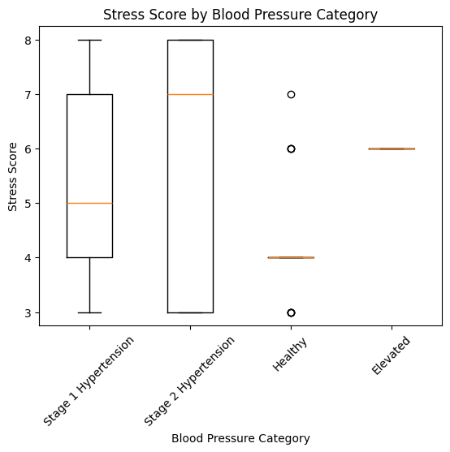

```python
plt.boxplot([hyper1_bp_df['Stress Level'], hyper2_bp_df['Stress Level'], healthy_bp_df['Stress Level'], elevated_bp_df['Stress Level']], tick_labels=df['Blood Pressure Category'].unique())
plt.xticks(rotation=45)
plt.xlabel('Blood Pressure Category')
plt.ylabel('Stress Score')
plt.title('Stress Score by Blood Pressure Category')
plt.show()
```

### **T-Test: Physical Activity and Quality of Sleep**

In this test we are going to be comparing quality of sleep between those who have high physical activty and those who don't.  
*Null Hypothesis*  
H1 = There will be no difference between the means of sleep quality of those who are more physcially active and those who aren't  
*Alternative Hypothesis*  
Ha = The mean sleep quality of those who are more physicaly active is higher than those who aren't as active

```python
active = df[df['Physical Activity Level'] >= 60]
inactive = df[df['Physical Activity Level'] < 60]

# High physical activity quality of sleep
active_sleep = active['Quality of Sleep']
# Low physical activity quality of sleep
inactive_sleep = inactive['Quality of Sleep']

# Means of both
display(active_sleep.mean())
display(inactive_sleep.mean())
```

```
np.float64(7.677570093457944)
```

```
np.float64(6.825)
```

The above data shows us that the mean quality of sleep for those who are more physically active is ~7.7 while for those who are less active it is ~6.8. This shows about a 0.9 difference in quality, but we need to perform a test to see how significat this is:

```python
# T-test
t_stat, p_val = stats.ttest_ind(active_sleep, inactive_sleep, equal_var=False)
display(p_val)
display(t_stat)
```

```
np.float64(2.3138595114359084e-11)
```

```
np.float64(6.967503736917795)
```

Analysizng the pvalue and results in general: Our p value is 2.314e-11 which is less than our significance level, 0.05. This means we can reject the null hypothesis and therefore there is a difference in sleep quality for those who are more active compared to those who are not. Since our t-stat is also quite large, it implies the difference between the means of our two groups is quite large.

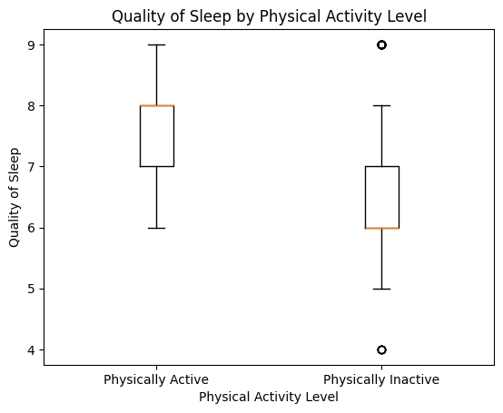

```python
# Box plot of active and inactive sleep qualities
plt.boxplot([active_sleep, inactive_sleep], tick_labels=['Physically Active', 'Physically Inactive'])
plt.xlabel('Physical Activity Level')
plt.ylabel('Quality of Sleep')
plt.title('Quality of Sleep by Physical Activity Level')
plt.show()
```

Through the box plot, we can see the median quality of sleep is lower for individuals who are physically inactive.

## **Determining Outliers**

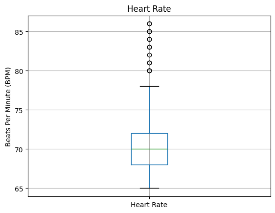

```python
df.boxplot(column=['Heart Rate'])
plt.title('Heart Rate')
plt.ylabel('Beats Per Minute (BPM)')
plt.show()
```

There are outliers for heart rate. We see that heart rates above 80 BPM are outliers.

```python
# Below are the people with heart rates that are outliers:
df[df['Heart Rate'] >= 80]
```

|  | Person ID | Gender | Age | Occupation | Sleep Duration | Quality of Sleep | Physical Activity Level | Stress Level | BMI Category | Blood Pressure | Heart Rate | Daily Steps | Sleep Disorder | Systolic | Diastolic | Blood Pressure Category | Age Group |
| --- | --- | --- | --- | --- | --- | --- | --- | --- | --- | --- | --- | --- | --- | --- | --- | --- | --- |
| 3 | 4 | M | 28 | Sales Representative | 5.9 | 4 | 30.0 | 8 | Obese | 140/90 | 85 | 3000 | Sleep Apnea | 140 | 90 | Stage 2 Hypertension | 25-34 |
| 4 | 5 | M | 28 | Sales Representative | 5.9 | 4 | 30.0 | 8 | Obese | 140/90 | 85 | 3000 | Sleep Apnea | 140 | 90 | Stage 2 Hypertension | 25-34 |
| 5 | 6 | M | 28 | Engineer | 5.9 | 4 | 30.0 | 8 | Obese | 140/90 | 85 | 3000 | Insomnia | 140 | 90 | Stage 2 Hypertension | 25-34 |
| 6 | 7 | M | 29 | Teacher | 6.3 | 6 | 40.0 | 7 | Obese | 140/90 | 82 | 3500 | Insomnia | 140 | 90 | Stage 2 Hypertension | 25-34 |
| 16 | 17 | F | 29 | Nurse | 6.5 | 5 | 40.0 | 7 | Normal | 132/87 | 80 | 4000 | Sleep Apnea | 132 | 87 | Stage 1 Hypertension | 25-34 |
| 18 | 19 | F | 29 | Nurse | 6.5 | 5 | 40.0 | 7 | Normal | 132/87 | 80 | 4000 | Insomnia | 132 | 87 | Stage 1 Hypertension | 25-34 |
| 80 | 81 | F | 34 | Scientist | 5.8 | 4 | 32.0 | 8 | Overweight | 131/86 | 81 | 5200 | Sleep Apnea | 131 | 86 | Stage 1 Hypertension | 25-34 |
| 81 | 82 | F | 34 | Scientist | 5.8 | 4 | 32.0 | 8 | Overweight | 131/86 | 81 | 5200 | Sleep Apnea | 131 | 86 | Stage 1 Hypertension | 25-34 |
| 93 | 94 | M | 35 | Lawyer | 7.4 | 7 | 60.0 | 5 | Obese | 135/88 | 84 | 3300 | Sleep Apnea | 135 | 88 | Stage 1 Hypertension | 35-44 |
| 145 | 146 | F | 38 | Lawyer | 7.4 | 7 | 60.0 | 5 | Obese | 135/88 | 84 | 3300 | Sleep Apnea | 135 | 88 | Stage 1 Hypertension | 35-44 |
| 147 | 148 | M | 39 | Engineer | 6.5 | 5 | 40.0 | 7 | Overweight | 132/87 | 80 | 4000 | Insomnia | 132 | 87 | Stage 1 Hypertension | 35-44 |
| 264 | 265 | M | 48 | Doctor | 7.3 | 7 | 65.0 | 5 | Obese | 142/92 | 83 | 3500 | Insomnia | 142 | 92 | Stage 2 Hypertension | 45-54 |
| 266 | 267 | M | 48 | Doctor | 7.3 | 7 | 65.0 | 5 | Obese | 142/92 | 83 | 3500 | Insomnia | 142 | 92 | Stage 2 Hypertension | 45-54 |
| 276 | 277 | M | 49 | Doctor | 8.1 | 9 | 85.0 | 3 | Obese | 139/91 | 86 | 3700 | Sleep Apnea | 139 | 91 | Stage 1 Hypertension | 45-54 |
| 277 | 278 | M | 49 | Doctor | 8.1 | 9 | 85.0 | 3 | Obese | 139/91 | 86 | 3700 | Sleep Apnea | 139 | 91 | Stage 1 Hypertension | 45-54 |

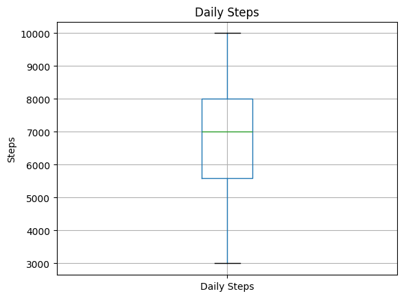

```python
df.boxplot(column=['Daily Steps'])
plt.title('Daily Steps')
plt.ylabel('Steps')
plt.show()
```

We see there are no outliers for daily steps

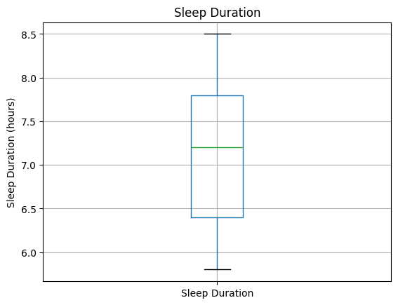

```python
df.boxplot(column=['Sleep Duration'])
plt.title('Sleep Duration')
plt.ylabel('Sleep Duration (hours)')
plt.show()
```

We see there are no outliers for sleep duration.

## **Feature Selection**

```python
# Dropping unnecessary features for modeling
df = df.drop(columns = ['Person ID', 'Blood Pressure', 'Age Group'])
```

'Person ID' is just an identifier, so it can be dropped. 'Blood Pressure' has already been converted into its systolic and diastolic numbers, so it can be dropped. 'Age Group', while we deemed useful initially, will not be essential to training our model because we can use the preexisting 'Age' feature instead, as it is also already numeric.

## **Feature Encoding**

```python
# Label encoding for BMI Category
bmi_order = {"Normal":0, "Overweight":1, "Obese":2}
df['BMI Category'] = df['BMI Category'].map(bmi_order)
# Label encoding for Blood Pressure Category
bp_order = {"Healthy":0, "Elevated":1, "Stage 1 Hypertension":2, "Stage 2 Hypertension":3, "Hypertension Crisis":4}
df['Blood Pressure Category'] = df['Blood Pressure Category'].map(bp_order)
# One-Hot encoding for Sleep Disorder
df = pd.get_dummies(df, columns=['Sleep Disorder'])
# One-Hot encoding for Gender
df = pd.get_dummies(df, columns=['Gender'])
# Too many Occupations for One-Hot encoding, so we will use target encoding (Seen next)
```

## **Preparing for Modeling**

To later test the decision tree model we build and avoid data leakage, the data is split into training and testing sets with 20% being test data. Target encoding is also done with y_train for both x_train and x_test to prevent possible data leakage.

```python
from sklearn.tree import DecisionTreeClassifier
from sklearn.model_selection import train_test_split
X = df.drop(columns=['Stress Level'])
y = df['Stress Level']
# Using 20% of the data as test data
X_train, X_test, y_train, y_test = train_test_split(X, y, test_size = 0.2, random_state = 42)
# We do target encoding for Occupation using the y_train labels to avoid data leakage
occupation_stress_means = y_train.groupby(X_train['Occupation']).mean()
X_train['Occupation'] = X_train['Occupation'].map(occupation_stress_means)
X_test['Occupation'] = X_test['Occupation'].map(occupation_stress_means)
```

## **Decision Tree Training**

```python
# Set random state for reproducibility
random_state = 42
# Initialize decision tree model
decision_tree = DecisionTreeClassifier(max_depth=5, random_state=random_state)
# Train the model
decision_tree.fit(X_train, y_train)
# Make predictions
y_pred = decision_tree.predict(X_test)
```

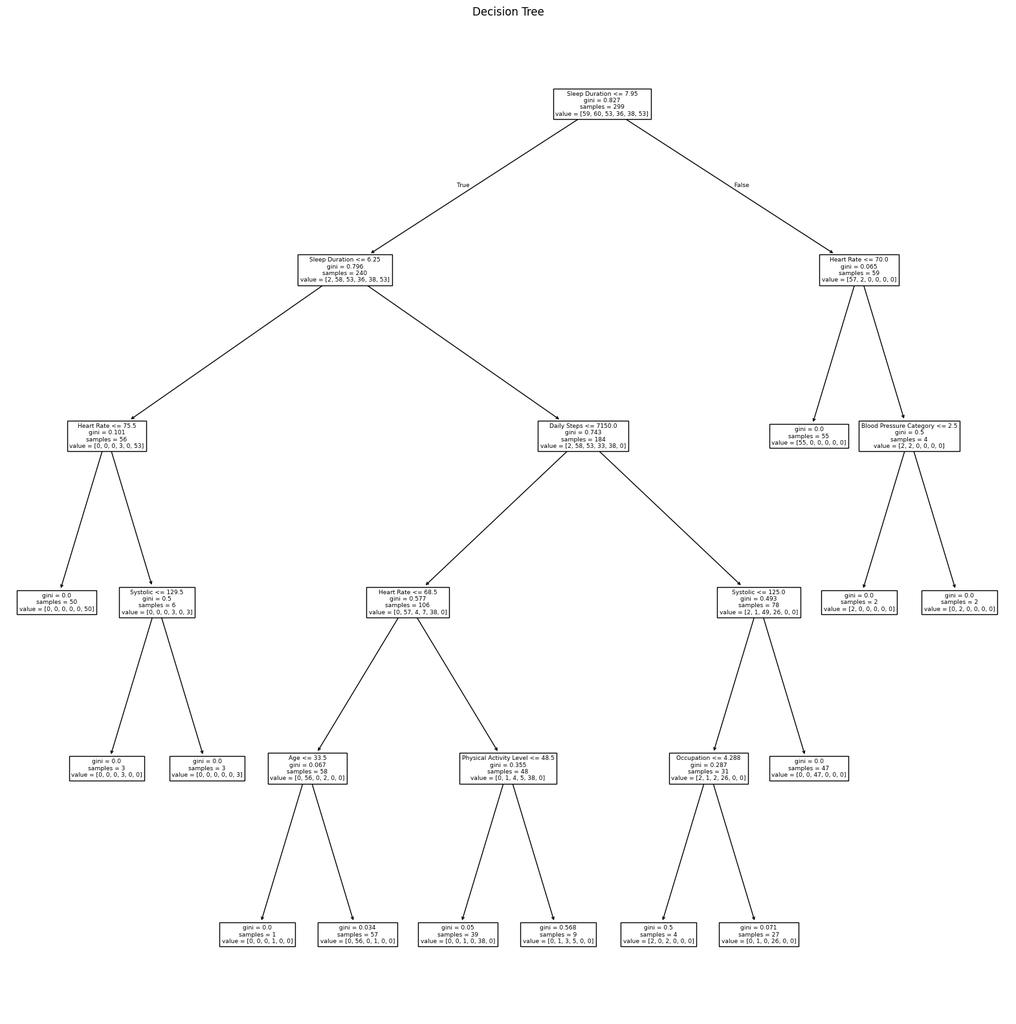

```python
# Create a visualization of the decision tree
from sklearn import tree
plt.figure(figsize=(20,20))
tree.plot_tree(decision_tree, feature_names=X_train.columns.tolist())
plt.title("Decision Tree")
plt.show()
```

Insights: The root of the desicion tree is split on Sleep Duration <= 7.95, an indicator that sleep duartion might have some of the biggest effects on stress. We can also note how, based on sample size, the large majority of patients sleep for under 7.95 (240 to 59). Some of the next splitting nodes are Heart Rate and Daily steps, implying they also have more importance over stress than the other features. Going down to the leaf nodes, we see that most of them have a gini score close to 0, which is what we want since it means we have a pure sample. A larger depth might add more branches to the path with higher gini scores. However, some of them have incredibly small sample sizes, like 1 and 2, which shows that we are overfitting a bit.

## **Model Evaluation**

```python
from sklearn.metrics import accuracy_score, classification_report
accuracy = accuracy_score(y_test, y_pred)
print(f"Accuracy: {accuracy:.4f}\n")
print("Classification report:")
print(classification_report(y_test, y_pred))
```

```
Accuracy: 0.9467

Classification report:
              precision    recall  f1-score   support

           3       1.00      1.00      1.00        12
           4       0.91      1.00      0.95        10
           5       1.00      0.79      0.88        14
           6       0.82      0.90      0.86        10
           7       0.92      1.00      0.96        12
           8       1.00      1.00      1.00        17

    accuracy                           0.95        75
   macro avg       0.94      0.95      0.94        75
weighted avg       0.95      0.95      0.95        75
```

Insights: The model evaluation shows that we have an overall 94.67% accuracy, which is pretty good. The prescision of each stress level on the left is pretty good all around, staying above 0.80%, howver our recall and f1 score shows that the model messes up 5 and 6 more often than the other stress levels, which isn't too bad because they are close to one another and in the middle of our range.

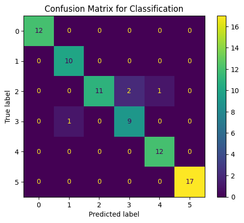

```python
# Create a confusion matrix to visualize model evaluation
from sklearn import metrics
confusion_matrix = metrics.confusion_matrix(y_test, y_pred)
confusion_matrix_norm = metrics.confusion_matrix(y_test, y_pred, normalize="all")
cm_display = metrics.ConfusionMatrixDisplay(confusion_matrix = confusion_matrix)
cm_display.plot()
plt.title("Confusion Matrix for Classification")
plt.show()
```

Insights: Our confusion matrix confirms the observations seen in the model evaulation. When compared to the values in the support column above, we see that the model has the same predicted and true values for most of the stress levels (where the graph numbers 0-5 correlate to stress levels 3-8), but does mess up the most in the middle with stress levels 5 and 6.

## **Check Overfitting**

When just evaluating the model with the test data set, we overlook whether the model is generalizing well. To verify if the model is overfitting, we must check the accuracy of the model using the training set and compare the overall accuracies.

```python
# Checking the accuracy of our model when using the training set
# High accuracy compared to test accuracy could imply overfitting
y_train_pred = decision_tree.predict(X_train)
accuracy_train = accuracy_score(y_train, y_train_pred)
print(f"Accuracy: {accuracy_train:.4f}\n")
print("Classification report:")
print(classification_report(y_train, y_train_pred))
```

```
Accuracy: 0.9699

Classification report:
              precision    recall  f1-score   support

           3       0.97      1.00      0.98        59
           4       0.98      0.97      0.97        60
           5       1.00      0.89      0.94        53
           6       0.88      0.97      0.92        36
           7       0.97      1.00      0.99        38
           8       1.00      1.00      1.00        53

    accuracy                           0.97       299
   macro avg       0.97      0.97      0.97       299
weighted avg       0.97      0.97      0.97       299
```

Insights: When using the training set for our model, we got an accuracy of 96.99%. When using the test set for our model, we got an accuracy of 94.67%. This is a small difference of just 2.32%, so our model is doing a pretty good job overall. So while there is some mild overfitting, it is still able to generalize well for new data.

## **Feature Importances**

With the decision tree model, we can find what features are the most important in deciding how to classify individuals into certain stress categories.

```python
# Extract importances
importances = decision_tree.feature_importances_

# Make a dictionary and then a dataframe to display importances
f_importance_dict = {"Feature" : X.columns, "Importance" : importances}
f_importance_df = pd.DataFrame(f_importance_dict).sort_values(by="Importance", ascending=False)
# Display importances

print("Feature importances:")
print(f_importance_df[:4])
```

```
Feature importances:
          Feature  Importance
2  Sleep Duration    0.431538
6      Heart Rate    0.190912
7     Daily Steps    0.158108
8        Systolic    0.139002
```

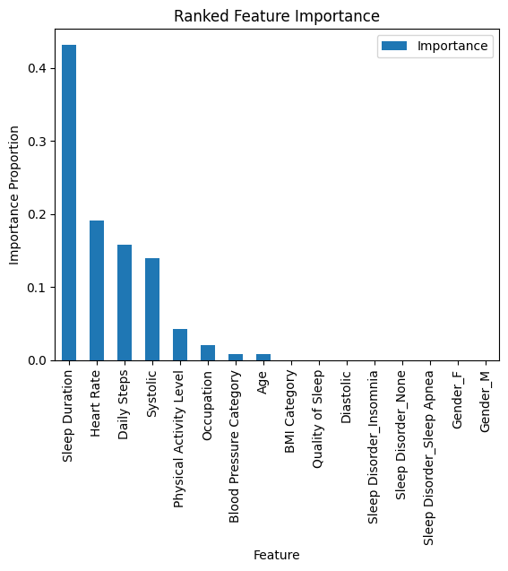

```python
# Chart feature importances in a bar plot
f_importance_df.plot(kind="bar", x="Feature", y="Importance", ylabel="Importance Proportion", title="Ranked Feature Importance")
```

Insights: The feature importances output and plot confirm our observation from the descision tree that sleep duration, at 43% importance, makes the most difference between stress levels, followed by heart rate at 19% importance, daily steps at 15% importance, and systolic at 13% importance. The rest of the features have very low or 0 importance, which isn't a bad thing but that might change slightly with higher depth level on the tree.

## **Insight Summary and Conclusions**

In the future, we can expand on this data analysis by using different models, exploring a comparison between blood pressure and sleep duration, seeing if any other feature affects sleep duration, or expanding our sample size as a whole. We could also work on fixing our overfitting by using a smaller tree depth or trying a random forest.